# Quant Assignment 5

### conclusion and visualization

The biggest difference in adjusted R-squared values didn’t happen when I changed any of the independent variables (although I didn’t include all the code here, I adjusted each of them and it made little difference), but when I used the log function on my dependent variable. HINCP had the highest skew rates, likely because of the nature of inequality in our country/state. Each of the models with the highest adjusted r-squared values had the log function applied to HINCP, with only extremely minor variations with other shifts.

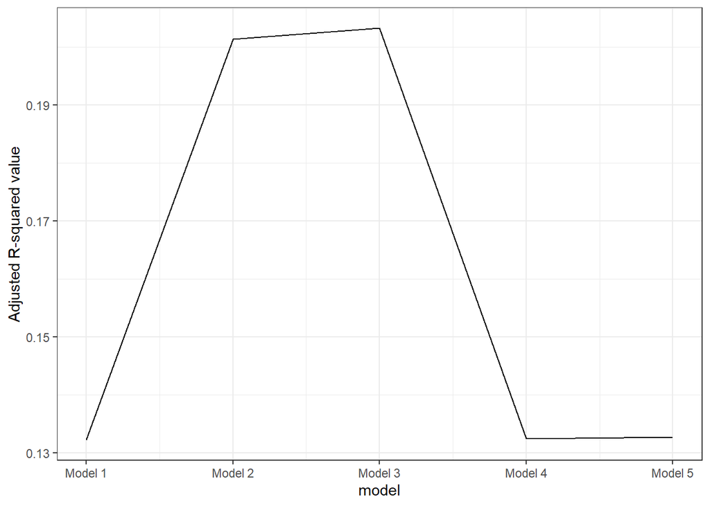

```r
ModelFit <- tibble(model = c(1, 2, 3, 4, 5),
                   R_square = c(summary(ogmodel)$adj.r.squared,
                                summary(logmodel1)$adj.r.squared,
                                summary(logmodel2)$adj.r.squared,
                                summary(logmodel3)$adj.r.squared,
                                summary(logmodel4)$adj.r.squared))

ggplot(ModelFit, aes(x = model, y = R_square)) +
  geom_line() +
  scale_x_continuous(breaks = breaks <- seq(1, 5, by = 1),
                   labels = paste("Model", breaks)) +
  scale_y_continuous(name = "Adjusted R-squared value") +
  theme_bw()
```